# LabWeek9

Mason Rossi

2023-06-01

### LIBRARIES, CLEAR, & Q1

```r
rm(list=ls())
setwd("/Users/masonrossi/Desktop/Econ 42/Week 9")
### Library ###
library(AER)
library(car)
library(doBy)
library(dplyr)
library(foreign)
library(ggplot2)
library(knitr)
library(sandwich)
library(stargazer)
library(XML)
library(readxl)
library(epiDisplay)
library(lmtest)
cse=function(reg) {
    rob=sqrt(diag(vcovHC(reg, type="HC1")))
    return(rob)
    }
df<-read.csv("beauty.csv")
```

### Q2

```r
df$looks_num<-ifelse(df$looks=="homely", 1,
                    ifelse(df$looks=="below average", 2,
                           ifelse(df$looks=="Average", 3,
                                  ifelse(df$looks=="Above average", 4, 5
                                  ))))
stargazer(df[c("looks_num","educ", "exper", "wage")], type="text")
```

```
============================================
Statistic   N    Mean  St. Dev.  Min   Max
--------------------------------------------
looks_num 1,260 3.186   0.685     1     5
educ      1,260 12.563  2.624     5     17
exper     1,260 18.206  11.963    0     48
wage      1,260 6.307   4.661   1.020 77.720
--------------------------------------------
```

There are 1,260 observations in total for all statistics, the mean of looks, educ, exper, and wage in order are 3.186, 12.563, 18.206, and 6.307. The standard deviation of looks, educ, exper, and wage in order are .685, 2.624, 11.963, and 4.661. Mean wage is 6.307 so the majority of people are relatively poor.

### Q3

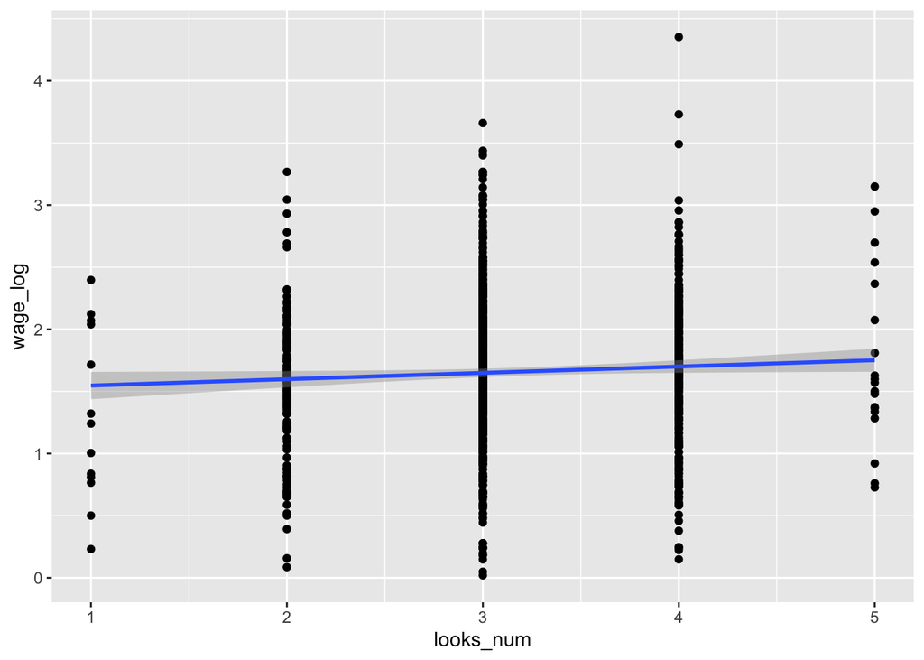

```r
df$wage_log<-log(df$wage)
ggplot(data=df,aes(x=looks_num,y=wage_log))+geom_point()+geom_smooth(method="lm")
```

Yes, there is a slightly positive linear relationship between looks and expected average wage.

### Q4

```r
df$looks_factor<-as.factor(df$looks_num)
fit1 <- lm(log(wage) ~ looks_num, data=df)
fit2 <- lm(log(wage) ~ looks_factor, data=df)
stargazer(fit1,fit2,type='text')
```

```
==================================================================
                                 Dependent variable:
                    ----------------------------------------------
                                      log(wage)
                             (1)                     (2)
------------------------------------------------------------------
looks_num                  0.051**
                           (0.024)

looks_factor2                                       0.194
                                                   (0.171)

looks_factor3                                      0.386**
                                                   (0.165)

looks_factor4                                      0.336**
                                                   (0.167)

looks_factor5                                      0.432**
                                                   (0.213)

Constant                   1.496***               1.312***
                           (0.080)                 (0.164)

------------------------------------------------------------------
Observations                1,260                   1,260
R2                          0.003                   0.014
Adjusted R2                 0.003                   0.011
Residual Std. Error   0.594 (df = 1258)       0.591 (df = 1255)
F Statistic         4.349** (df = 1; 1258) 4.429*** (df = 4; 1255)
==================================================================
Note:                                  *p<0.1; **p<0.05; ***p<0.01
```

Q5: For reg1, when your looks increase by one, you are expected to earn 5.1% more. For reg2, holding homely looks as our constant, we see how much more you are expected to earn based on better looks versus homely. With below average looks, there is not a significant difference in earnings versus homely. For average looks, there is a statistically significant difference in earnings to 95% where you are expected to earn 38.6% more than someone who is homely. For above average looks, there is a statistically significant difference in earnings to 95% where you are expected to earn 33.6% more than someone who is homely. For handsome looks, there is a statistically significant difference in earnings to 95% where you are expected to earn 43.2% more than someone who is homely.

Q6: We can say from just this regression that better looks do result in a higher average wage. However, there are other variables that are likely not factored out of our error term that result in OVB. For example, someone who has the money to spend on themselves to better their looks ie through makeup, facial regimes, and better healthcare, likely lives in an area where there are higher paying jobs because they have wealth to begin with where they will have better access to educational resources where they will earn more. Additionally, someone who lives in a big city will have more people in the city to be able to recognize them for their looks to benefit them through job hiring.

### Q7

```r
fit1 <- lm(log(wage) ~ looks_num, data=df)
fit2 <- lm(log(wage) ~ looks_factor, data=df)
fit3 <- lm(log(wage) ~ looks_num + bigcity, data=df)
fit4 <- lm(log(wage) ~ looks_num + bigcity + smllcity, data=df)
stargazer(fit1,fit2,fit3,fit4, type='text')
```

```
====================================================================================================================
                                                          Dependent variable:
                    ------------------------------------------------------------------------------------------------
                                                               log(wage)
                             (1)                     (2)                     (3)                      (4)
--------------------------------------------------------------------------------------------------------------------
looks_num                  0.051**                                         0.050**                  0.049**
                           (0.024)                                         (0.024)                  (0.024)

looks_factor2                                       0.194
                                                   (0.171)

looks_factor3                                      0.386**
                                                   (0.165)

looks_factor4                                      0.336**
                                                   (0.167)

looks_factor5                                      0.432**
                                                   (0.213)

bigcity                                                                    0.277***                 0.362***
                                                                           (0.040)                  (0.045)

smllcity                                                                                            0.142***
                                                                                                    (0.038)

Constant                   1.496***               1.312***                 1.440***                 1.356***
                           (0.080)                 (0.164)                 (0.079)                  (0.081)

--------------------------------------------------------------------------------------------------------------------
Observations                1,260                   1,260                   1,260                    1,260
R2                          0.003                   0.014                   0.041                    0.051
Adjusted R2                 0.003                   0.011                   0.039                    0.049
Residual Std. Error   0.594 (df = 1258)       0.591 (df = 1255)       0.583 (df = 1257)        0.580 (df = 1256)
F Statistic         4.349** (df = 1; 1258) 4.429*** (df = 4; 1255) 26.584*** (df = 2; 1257) 22.626*** (df = 3; 1256)
====================================================================================================================
Note:                                                                                    *p<0.1; **p<0.05; ***p<0.01
```

Q8: We see that with the addition of both big cities and small cities, our adjusted R^2 increases greatly to .049 which means that fit4 best explains our data because it best explains the variability of our data. Q9: If we are to assume that gender is encoded as binary where male=0 female=1 we do: fit3 <- lm(log(wage)~looks_num + female, data = df)

### Q10

```r
fit4 <- lm(log(wage) ~ looks_num + bigcity + smllcity, data=df)
stargazer(fit4, type='text')
```

```
===============================================
                        Dependent variable:
                    ---------------------------
                             log(wage)
-----------------------------------------------
looks_num                     0.049**
                              (0.024)

bigcity                      0.362***
                              (0.045)

smllcity                     0.142***
                              (0.038)

Constant                     1.356***
                              (0.081)

-----------------------------------------------
Observations                   1,260
R2                             0.051
Adjusted R2                    0.049
Residual Std. Error      0.580 (df = 1256)
F Statistic          22.626*** (df = 3; 1256)
===============================================
Note:               *p<0.1; **p<0.05; ***p<0.01
```

### Q11

```r
fit5 <- lm(log(wage)~looks_num + female, data = df)
stargazer(fit5, type='text')
```

```
===============================================
                        Dependent variable:
                    ---------------------------
                             log(wage)
-----------------------------------------------
looks_num                    0.057***
                              (0.022)

female                       -0.548***
                              (0.032)

Constant                     1.665***
                              (0.072)

-----------------------------------------------
Observations                   1,260
R2                             0.196
Adjusted R2                    0.195
Residual Std. Error      0.534 (df = 1257)
F Statistic          153.086*** (df = 2; 1257)
===============================================
Note:               *p<0.1; **p<0.05; ***p<0.01
```

### Q12

```r
df$handsome<-ifelse(df$looks=="handsome",1,0)
df$homely<-ifelse(df$looks=="homely",1,0)
```

### Q13

```r
fit6<-lm(log(wage)~handsome+bigcity+smllcity,data=df)
fit7<-lm(log(wage)~homely+bigcity+smllcity,data=df)
stargazer(fit6,fit7, type='text')
```

```
============================================================
                                    Dependent variable:
                                ----------------------------
                                         log(wage)
                                     (1)            (2)
------------------------------------------------------------
handsome                            0.073
                                   (0.134)

homely                                           -0.360**
                                                  (0.162)

bigcity                            0.362***      0.363***
                                   (0.046)        (0.045)

smllcity                           0.143***      0.140***
                                   (0.038)        (0.038)

Constant                           1.512***      1.518***
                                   (0.029)        (0.029)

------------------------------------------------------------
Observations                        1,260          1,260
R2                                  0.048          0.052
Adjusted R2                         0.046          0.050
Residual Std. Error (df = 1256)     0.581          0.580
F Statistic (df = 3; 1256)        21.232***      22.868***
============================================================
Note:                            *p<0.1; **p<0.05; ***p<0.01
```

Fit 6 shows that if you are handsome, holding homely and other looks constant, you are not expected to earn an amount statistically significant to other looks combined. However, for homely in fit7, we see that you are expected to earn on average, 36% less than other looks with statistical significance of 95%.